# LSTM model of StockData

## LSTM Parameter: dropout rate

```
split_date: 2017-10-13 00:00:00
3170/3170 - 5s - loss: 0.0200 - 5s/epoch - 2ms/step
3170/3170 - 4s - loss: 0.0157 - 4s/epoch - 1ms/step
3170/3170 - 5s - loss: 0.0146 - 5s/epoch - 1ms/step
3170/3170 - 5s - loss: 0.0141 - 5s/epoch - 1ms/step
3170/3170 - 4s - loss: 0.0137 - 4s/epoch - 1ms/step
```

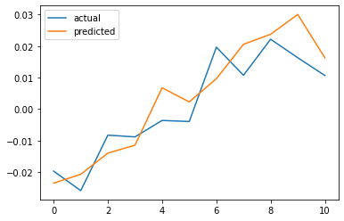

```
split_date: 2017-10-13 00:00:00
3170/3170 - 5s - loss: 0.0216 - 5s/epoch - 2ms/step
3170/3170 - 4s - loss: 0.0159 - 4s/epoch - 1ms/step
3170/3170 - 4s - loss: 0.0144 - 4s/epoch - 1ms/step
3170/3170 - 4s - loss: 0.0137 - 4s/epoch - 1ms/step
3170/3170 - 4s - loss: 0.0135 - 4s/epoch - 1ms/step
```

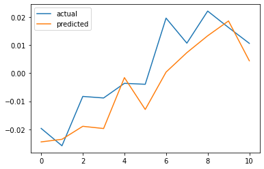

```
split_date: 2017-10-13 00:00:00
3170/3170 - 5s - loss: 0.0269 - 5s/epoch - 2ms/step
3170/3170 - 4s - loss: 0.0166 - 4s/epoch - 1ms/step
3170/3170 - 4s - loss: 0.0149 - 4s/epoch - 1ms/step
3170/3170 - 4s - loss: 0.0141 - 4s/epoch - 1ms/step
3170/3170 - 5s - loss: 0.0138 - 5s/epoch - 1ms/step
```

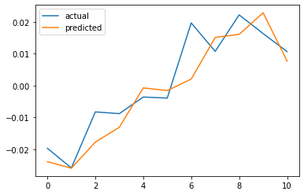

```
split_date: 2017-10-13 00:00:00
3170/3170 - 5s - loss: 0.0254 - 5s/epoch - 2ms/step
3170/3170 - 4s - loss: 0.0165 - 4s/epoch - 1ms/step
3170/3170 - 4s - loss: 0.0149 - 4s/epoch - 1ms/step
3170/3170 - 4s - loss: 0.0142 - 4s/epoch - 1ms/step
3170/3170 - 4s - loss: 0.0140 - 4s/epoch - 1ms/step
```

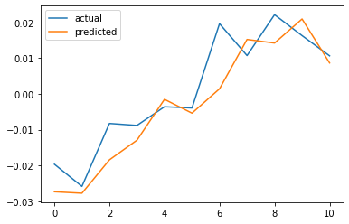

```
split_date: 2017-10-13 00:00:00
3170/3170 - 5s - loss: 0.0285 - 5s/epoch - 2ms/step
3170/3170 - 5s - loss: 0.0165 - 5s/epoch - 1ms/step
3170/3170 - 5s - loss: 0.0150 - 5s/epoch - 2ms/step
3170/3170 - 4s - loss: 0.0144 - 4s/epoch - 1ms/step
3170/3170 - 4s - loss: 0.0142 - 4s/epoch - 1ms/step
```

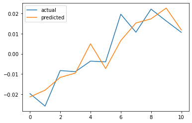

```
split_date: 2017-10-13 00:00:00
3170/3170 - 5s - loss: 0.0262 - 5s/epoch - 2ms/step
3170/3170 - 4s - loss: 0.0166 - 4s/epoch - 1ms/step
3170/3170 - 4s - loss: 0.0152 - 4s/epoch - 1ms/step
3170/3170 - 4s - loss: 0.0147 - 4s/epoch - 1ms/step
3170/3170 - 4s - loss: 0.0144 - 4s/epoch - 1ms/step
```

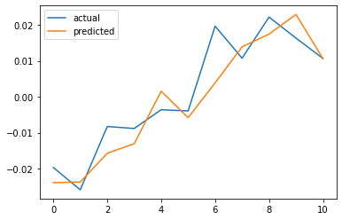

```
split_date: 2017-10-13 00:00:00
3170/3170 - 5s - loss: 0.0255 - 5s/epoch - 2ms/step
3170/3170 - 4s - loss: 0.0167 - 4s/epoch - 1ms/step
3170/3170 - 4s - loss: 0.0155 - 4s/epoch - 1ms/step
3170/3170 - 4s - loss: 0.0149 - 4s/epoch - 1ms/step
3170/3170 - 4s - loss: 0.0146 - 4s/epoch - 1ms/step
```

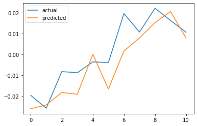

```
split_date: 2017-10-13 00:00:00
3170/3170 - 5s - loss: 0.0257 - 5s/epoch - 2ms/step
3170/3170 - 4s - loss: 0.0168 - 4s/epoch - 1ms/step
3170/3170 - 5s - loss: 0.0157 - 5s/epoch - 1ms/step
3170/3170 - 5s - loss: 0.0151 - 5s/epoch - 2ms/step
3170/3170 - 5s - loss: 0.0148 - 5s/epoch - 2ms/step
```

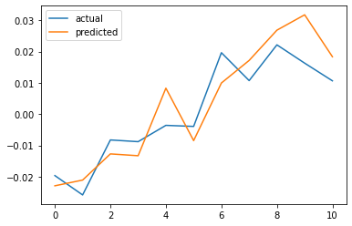

```
split_date: 2017-10-13 00:00:00
3170/3170 - 5s - loss: 0.0318 - 5s/epoch - 2ms/step
3170/3170 - 4s - loss: 0.0174 - 4s/epoch - 1ms/step
3170/3170 - 4s - loss: 0.0163 - 4s/epoch - 1ms/step
3170/3170 - 4s - loss: 0.0155 - 4s/epoch - 1ms/step
3170/3170 - 4s - loss: 0.0151 - 4s/epoch - 1ms/step
```

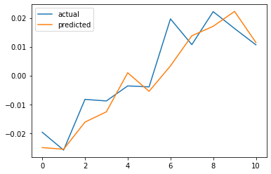

```
split_date: 2017-10-13 00:00:00
3170/3170 - 5s - loss: 0.0306 - 5s/epoch - 2ms/step
3170/3170 - 4s - loss: 0.0176 - 4s/epoch - 1ms/step
3170/3170 - 4s - loss: 0.0165 - 4s/epoch - 1ms/step
3170/3170 - 4s - loss: 0.0155 - 4s/epoch - 1ms/step
3170/3170 - 4s - loss: 0.0155 - 4s/epoch - 1ms/step
```

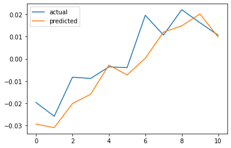

```
split_date: 2017-10-13 00:00:00
3170/3170 - 5s - loss: 0.0307 - 5s/epoch - 2ms/step
3170/3170 - 4s - loss: 0.0182 - 4s/epoch - 1ms/step
3170/3170 - 4s - loss: 0.0169 - 4s/epoch - 1ms/step
3170/3170 - 4s - loss: 0.0163 - 4s/epoch - 1ms/step
3170/3170 - 4s - loss: 0.0158 - 4s/epoch - 1ms/step
```

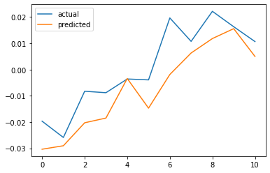

```
split_date: 2017-10-13 00:00:00
3170/3170 - 5s - loss: 0.0312 - 5s/epoch - 2ms/step
3170/3170 - 5s - loss: 0.0185 - 5s/epoch - 1ms/step
3170/3170 - 5s - loss: 0.0173 - 5s/epoch - 1ms/step
3170/3170 - 4s - loss: 0.0166 - 4s/epoch - 1ms/step
3170/3170 - 4s - loss: 0.0161 - 4s/epoch - 1ms/step
```

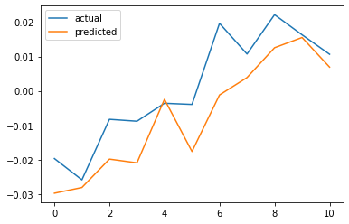

```
split_date: 2017-10-13 00:00:00
3170/3170 - 5s - loss: 0.0407 - 5s/epoch - 2ms/step
3170/3170 - 4s - loss: 0.0196 - 4s/epoch - 1ms/step
3170/3170 - 4s - loss: 0.0182 - 4s/epoch - 1ms/step
3170/3170 - 5s - loss: 0.0171 - 5s/epoch - 1ms/step
3170/3170 - 4s - loss: 0.0164 - 4s/epoch - 1ms/step
```

[8 more figures not shown]

```python
dropout_lst = np.arange(0, 1, 0.05)
dropout_dic = {}

for dropout in dropout_lst:
    def this_build_model(inputs, output_size, neurons, activ_func="linear",
                         dropout=dropout, loss="mae", optimizer="adam"):
        model = Sequential()

        model.add(LSTM(neurons, input_shape=(inputs.shape[1], inputs.shape[2])))
        model.add(Dropout(dropout))
        model.add(Dense(units=output_size))
        model.add(Activation(activ_func))

        model.compile(loss="mae", optimizer=optimizer)
        return model

    split_date = list(df["Date"][-(2*window_len+1):])[0]
    print("split_date:",split_date)

    #Split the training and test set
    training_set, test_set = df[df['Date'] < split_date], df[df['Date'] >= split_date]
    training_set = training_set.drop(['Date','Label', 'OpenInt'], 1)
    test_set = test_set.drop(['Date','Label','OpenInt'], 1)

    #Create windows for training
    LSTM_training_inputs = []
    for i in range(len(training_set)-window_len):
        temp_set = training_set[i:(i+window_len)].copy()

        for col in list(temp_set):
            temp_set[col] = temp_set[col]/temp_set[col].iloc[0] - 1

        LSTM_training_inputs.append(temp_set)
    LSTM_training_inputs
    LSTM_training_outputs = (training_set['Close'][window_len:].values/training_set[
        'Close'][:-window_len].values)-1

    LSTM_training_inputs = [np.array(LSTM_training_input) for LSTM_training_input in LSTM_training_inputs]
    LSTM_training_inputs = np.array(LSTM_training_inputs)

    # Create windows for testing
    LSTM_test_inputs = []
    for i in range(len(test_set)-window_len):
        temp_set = test_set[i:(i+window_len)].copy()

        for col in list(temp_set):
            temp_set[col] = temp_set[col]/temp_set[col].iloc[0] - 1

        LSTM_test_inputs.append(temp_set)
    LSTM_test_outputs = (test_set['Close'][window_len:].values/test_set['Close'][:-window_len].values)-1

    LSTM_test_inputs = [np.array(LSTM_test_inputs) for LSTM_test_inputs in LSTM_test_inputs]
    LSTM_test_inputs = np.array(LSTM_test_inputs)

    # initialise model architecture
    nn_model = this_build_model(LSTM_training_inputs, output_size=1, neurons = 32)
    # model output is next price normalised to 10th previous closing price train model on data
    # note: eth_history contains information on the training error per epoch
    nn_history = nn_model.fit(LSTM_training_inputs, LSTM_training_outputs,
                                epochs=5, batch_size=1, verbose=2, shuffle=True)
    plt.plot(LSTM_test_outputs, label = "actual")
    plt.plot(nn_model.predict(LSTM_test_inputs), label = "predicted")
    plt.legend()
    plt.show()
    MAE = mean_absolute_error(LSTM_test_outputs, nn_model.predict(LSTM_test_inputs))
    dropout_dic[dropout] = MAE
dropout_result = pd.DataFrame(dropout_dic.values(), dropout_dic.keys()).rename(columns={0: "MAE"})
```

```
           MAE
0.85  0.004235
```

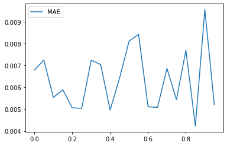

```python
print(dropout_result.loc[dropout_result["MAE"] == dropout_result["MAE"].min()])
dropout_result.plot()
```

Dropout regularization is the fraction that we randomly "dropping out" unit activations in a single network for each single gradient step, the higher the dropout is, the stronger the regularization the it performs.

## LSTM Parameter: optimizer

```
split_date: 2017-10-13 00:00:00
3170/3170 - 5s - loss: 0.0371 - 5s/epoch - 1ms/step
3170/3170 - 4s - loss: 0.0255 - 4s/epoch - 1ms/step
3170/3170 - 4s - loss: 0.0234 - 4s/epoch - 1ms/step
3170/3170 - 4s - loss: 0.0224 - 4s/epoch - 1ms/step
3170/3170 - 4s - loss: 0.0214 - 4s/epoch - 1ms/step
```

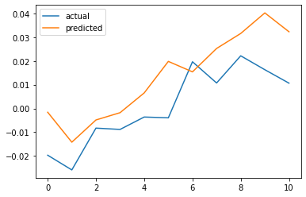

```
split_date: 2017-10-13 00:00:00
3170/3170 - 5s - loss: 0.0233 - 5s/epoch - 2ms/step
3170/3170 - 4s - loss: 0.0155 - 4s/epoch - 1ms/step
3170/3170 - 4s - loss: 0.0143 - 4s/epoch - 1ms/step
3170/3170 - 4s - loss: 0.0140 - 4s/epoch - 1ms/step
3170/3170 - 4s - loss: 0.0139 - 4s/epoch - 1ms/step
```

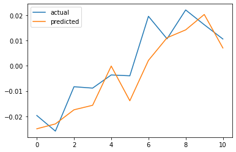

```
split_date: 2017-10-13 00:00:00
3170/3170 - 5s - loss: 0.0229 - 5s/epoch - 2ms/step
3170/3170 - 4s - loss: 0.0161 - 4s/epoch - 1ms/step
3170/3170 - 4s - loss: 0.0147 - 4s/epoch - 1ms/step
3170/3170 - 4s - loss: 0.0139 - 4s/epoch - 1ms/step
3170/3170 - 4s - loss: 0.0139 - 4s/epoch - 1ms/step
```

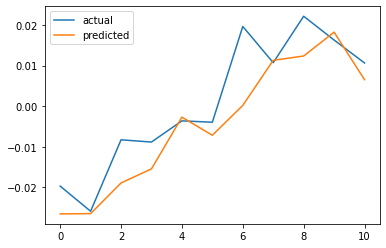

```
split_date: 2017-10-13 00:00:00
3170/3170 - 6s - loss: 0.1043 - 6s/epoch - 2ms/step
3170/3170 - 5s - loss: 0.0845 - 5s/epoch - 1ms/step
3170/3170 - 4s - loss: 0.0722 - 4s/epoch - 1ms/step
3170/3170 - 4s - loss: 0.0642 - 4s/epoch - 1ms/step
3170/3170 - 4s - loss: 0.0599 - 4s/epoch - 1ms/step
```

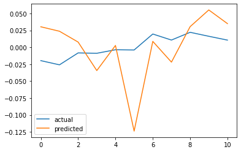

```
split_date: 2017-10-13 00:00:00
3170/3170 - 5s - loss: 0.0420 - 5s/epoch - 2ms/step
3170/3170 - 4s - loss: 0.0356 - 4s/epoch - 1ms/step
3170/3170 - 4s - loss: 0.0338 - 4s/epoch - 1ms/step
3170/3170 - 4s - loss: 0.0322 - 4s/epoch - 1ms/step
3170/3170 - 4s - loss: 0.0319 - 4s/epoch - 1ms/step
```

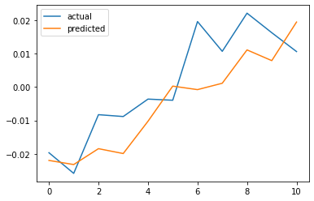

```
split_date: 2017-10-13 00:00:00
3170/3170 - 5s - loss: 0.0302 - 5s/epoch - 2ms/step
3170/3170 - 4s - loss: 0.0210 - 4s/epoch - 1ms/step
3170/3170 - 4s - loss: 0.0183 - 4s/epoch - 1ms/step
3170/3170 - 4s - loss: 0.0174 - 4s/epoch - 1ms/step
3170/3170 - 4s - loss: 0.0161 - 4s/epoch - 1ms/step
```

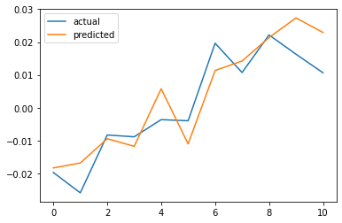

```
split_date: 2017-10-13 00:00:00
3170/3170 - 5s - loss: 0.0227 - 5s/epoch - 2ms/step
3170/3170 - 5s - loss: 0.0157 - 5s/epoch - 1ms/step
3170/3170 - 4s - loss: 0.0144 - 4s/epoch - 1ms/step
3170/3170 - 4s - loss: 0.0140 - 4s/epoch - 1ms/step
3170/3170 - 4s - loss: 0.0137 - 4s/epoch - 1ms/step
```

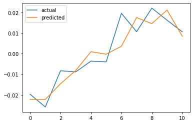

```
split_date: 2017-10-13 00:00:00
3170/3170 - 5s - loss: 0.0360 - 5s/epoch - 2ms/step
3170/3170 - 4s - loss: 0.0359 - 4s/epoch - 1ms/step
3170/3170 - 4s - loss: 0.0359 - 4s/epoch - 1ms/step
3170/3170 - 4s - loss: 0.0359 - 4s/epoch - 1ms/step
3170/3170 - 5s - loss: 0.0359 - 5s/epoch - 1ms/step
```

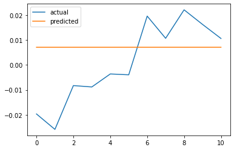

```python
optimizer_lst = ["sgd", "rmsprop", "adam", "adadelta", "adagrad", "adamax", "nadam", "ftrl"]
optimizer_dic = {}

for optimizer in optimizer_lst:
    def this_build_model(inputs, output_size, neurons, activ_func="linear",
                         dropout=0.10, loss="mae", optimizer=optimizer):
        model = Sequential()

        model.add(LSTM(neurons, input_shape=(inputs.shape[1], inputs.shape[2])))
        model.add(Dropout(dropout))
        model. add(Dense(units=output_size))
        model.add(Activation(activ_func))

        model.compile(loss="mae", optimizer=optimizer)
        return model

    split_date = list(df["Date"][-(2*window_len+1):])[0]
    print("split_date:",split_date)

    #Split the training and test set
    training_set, test_set = df[df['Date'] < split_date], df[df['Date'] >= split_date]
    training_set = training_set.drop(['Date','Label', 'OpenInt'], 1)
    test_set = test_set.drop(['Date','Label','OpenInt'], 1)

    #Create windows for training
    LSTM_training_inputs = []
    for i in range(len(training_set)-window_len):
        temp_set = training_set[i:(i+window_len)].copy()

        for col in list(temp_set):
            temp_set[col] = temp_set[col]/temp_set[col].iloc[0] - 1

        LSTM_training_inputs.append(temp_set)
    LSTM_training_inputs
    LSTM_training_outputs = (training_set['Close'][window_len:].values/training_set[
        'Close'][:-window_len].values)-1

    LSTM_training_inputs = [np.array(LSTM_training_input) for LSTM_training_input in LSTM_training_inputs]
    LSTM_training_inputs = np.array(LSTM_training_inputs)

    # Create windows for testing
    LSTM_test_inputs = []
    for i in range(len(test_set)-window_len):
        temp_set = test_set[i:(i+window_len)].copy()

        for col in list(temp_set):
            temp_set[col] = temp_set[col]/temp_set[col].iloc[0] - 1

        LSTM_test_inputs.append(temp_set)
    LSTM_test_outputs = (test_set['Close'][window_len:].values/test_set['Close'][:-window_len].values)-1

    LSTM_test_inputs = [np.array(LSTM_test_inputs) for LSTM_test_inputs in LSTM_test_inputs]
    LSTM_test_inputs = np.array(LSTM_test_inputs)

    # initialise model architecture
    nn_model = this_build_model(LSTM_training_inputs, output_size=1, neurons = 32)
    # model output is next price normalised to 10th previous closing price train model on data
    # note: eth_history contains information on the training error per epoch
    nn_history = nn_model.fit(LSTM_training_inputs, LSTM_training_outputs,
                                epochs=5, batch_size=1, verbose=2, shuffle=True)
    plt.plot(LSTM_test_outputs, label = "actual")
    plt.plot(nn_model.predict(LSTM_test_inputs), label = "predicted")
    plt.legend()
    plt.show()
    MAE = mean_absolute_error(LSTM_test_outputs, nn_model.predict(LSTM_test_inputs))
    optimizer_dic[optimizer] = MAE
optimizer_result = pd.DataFrame(optimizer_dic.values(), optimizer_dic.keys()).rename(columns={0: "MAE"})
```

```
            MAE
nadam  0.005371
```

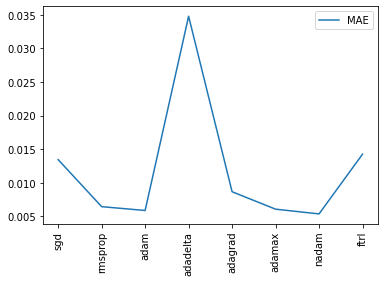

```python
print(optimizer_result.loc[optimizer_result["MAE"] == optimizer_result["MAE"].min()])
optimizer_result.plot(rot=90)
```

An optimizer is one of the two arguments required for compiling our model. Here, we would choose `nadam` as our optimizer since it generates lowest error.

## LSTM Parameter: nn layers/architecture

```
split_date: 2017-10-13 00:00:00
3170/3170 - 5s - loss: 0.0246 - 5s/epoch - 2ms/step
3170/3170 - 4s - loss: 0.0163 - 4s/epoch - 1ms/step
3170/3170 - 4s - loss: 0.0146 - 4s/epoch - 1ms/step
3170/3170 - 4s - loss: 0.0141 - 4s/epoch - 1ms/step
3170/3170 - 4s - loss: 0.0140 - 4s/epoch - 1ms/step
```

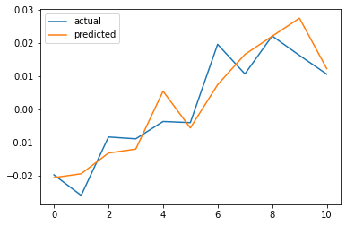

```
split_date: 2017-10-13 00:00:00
3170/3170 - 5s - loss: 0.0233 - 5s/epoch - 2ms/step
3170/3170 - 5s - loss: 0.0154 - 5s/epoch - 1ms/step
3170/3170 - 4s - loss: 0.0144 - 4s/epoch - 1ms/step
3170/3170 - 4s - loss: 0.0139 - 4s/epoch - 1ms/step
3170/3170 - 4s - loss: 0.0136 - 4s/epoch - 1ms/step
```

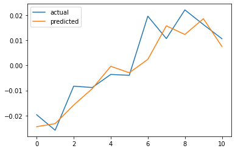

```
split_date: 2017-10-13 00:00:00
3170/3170 - 5s - loss: 0.0248 - 5s/epoch - 2ms/step
3170/3170 - 4s - loss: 0.0157 - 4s/epoch - 1ms/step
3170/3170 - 4s - loss: 0.0145 - 4s/epoch - 1ms/step
3170/3170 - 4s - loss: 0.0140 - 4s/epoch - 1ms/step
3170/3170 - 4s - loss: 0.0138 - 4s/epoch - 1ms/step
```

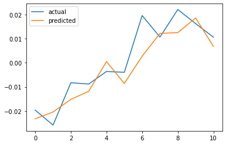

```
split_date: 2017-10-13 00:00:00
3170/3170 - 5s - loss: 0.0236 - 5s/epoch - 2ms/step
3170/3170 - 4s - loss: 0.0157 - 4s/epoch - 1ms/step
3170/3170 - 4s - loss: 0.0145 - 4s/epoch - 1ms/step
3170/3170 - 5s - loss: 0.0141 - 5s/epoch - 1ms/step
3170/3170 - 4s - loss: 0.0138 - 4s/epoch - 1ms/step
```

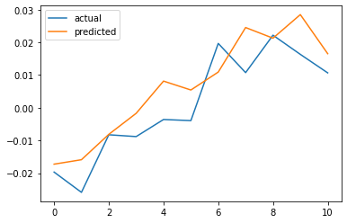

```
split_date: 2017-10-13 00:00:00
3170/3170 - 5s - loss: 0.0225 - 5s/epoch - 2ms/step
3170/3170 - 4s - loss: 0.0156 - 4s/epoch - 1ms/step
3170/3170 - 4s - loss: 0.0145 - 4s/epoch - 1ms/step
3170/3170 - 4s - loss: 0.0139 - 4s/epoch - 1ms/step
3170/3170 - 4s - loss: 0.0139 - 4s/epoch - 1ms/step
```

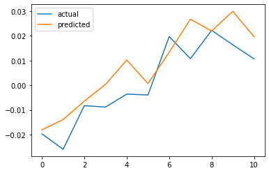

```
split_date: 2017-10-13 00:00:00
3170/3170 - 5s - loss: 0.0231 - 5s/epoch - 1ms/step
3170/3170 - 4s - loss: 0.0158 - 4s/epoch - 1ms/step
3170/3170 - 4s - loss: 0.0143 - 4s/epoch - 1ms/step
3170/3170 - 5s - loss: 0.0140 - 5s/epoch - 2ms/step
3170/3170 - 4s - loss: 0.0138 - 4s/epoch - 1ms/step
```

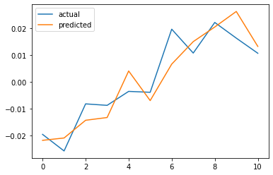

```
split_date: 2017-10-13 00:00:00
3170/3170 - 5s - loss: 0.0229 - 5s/epoch - 1ms/step
3170/3170 - 4s - loss: 0.0156 - 4s/epoch - 1ms/step
3170/3170 - 4s - loss: 0.0145 - 4s/epoch - 1ms/step
3170/3170 - 4s - loss: 0.0142 - 4s/epoch - 1ms/step
3170/3170 - 4s - loss: 0.0140 - 4s/epoch - 1ms/step
```

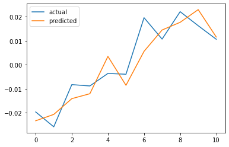

```
split_date: 2017-10-13 00:00:00
3170/3170 - 5s - loss: 0.0210 - 5s/epoch - 1ms/step
3170/3170 - 4s - loss: 0.0155 - 4s/epoch - 1ms/step
3170/3170 - 4s - loss: 0.0145 - 4s/epoch - 1ms/step
3170/3170 - 4s - loss: 0.0139 - 4s/epoch - 1ms/step
3170/3170 - 4s - loss: 0.0138 - 4s/epoch - 1ms/step
```

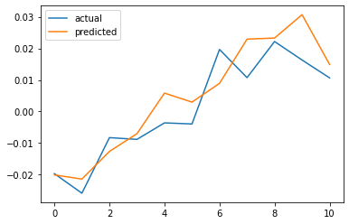

```
split_date: 2017-10-13 00:00:00
3170/3170 - 6s - loss: 0.0216 - 6s/epoch - 2ms/step
3170/3170 - 4s - loss: 0.0156 - 4s/epoch - 1ms/step
3170/3170 - 4s - loss: 0.0144 - 4s/epoch - 1ms/step
3170/3170 - 5s - loss: 0.0141 - 5s/epoch - 1ms/step
3170/3170 - 4s - loss: 0.0137 - 4s/epoch - 1ms/step
```

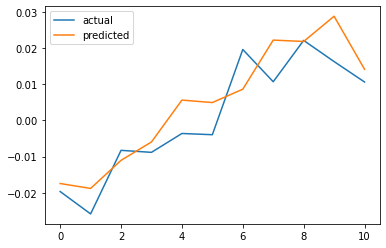

```
split_date: 2017-10-13 00:00:00
3170/3170 - 5s - loss: 0.0218 - 5s/epoch - 2ms/step
3170/3170 - 4s - loss: 0.0154 - 4s/epoch - 1ms/step
3170/3170 - 4s - loss: 0.0143 - 4s/epoch - 1ms/step
3170/3170 - 4s - loss: 0.0143 - 4s/epoch - 1ms/step
3170/3170 - 4s - loss: 0.0138 - 4s/epoch - 1ms/step
```

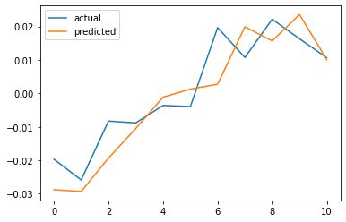

```
split_date: 2017-10-13 00:00:00
3170/3170 - 5s - loss: 0.0226 - 5s/epoch - 2ms/step
3170/3170 - 5s - loss: 0.0155 - 5s/epoch - 2ms/step
3170/3170 - 4s - loss: 0.0145 - 4s/epoch - 1ms/step
3170/3170 - 4s - loss: 0.0141 - 4s/epoch - 1ms/step
3170/3170 - 4s - loss: 0.0140 - 4s/epoch - 1ms/step
```

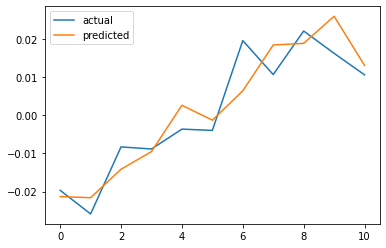

```
split_date: 2017-10-13 00:00:00
3170/3170 - 5s - loss: 0.0207 - 5s/epoch - 2ms/step
3170/3170 - 4s - loss: 0.0153 - 4s/epoch - 1ms/step
3170/3170 - 4s - loss: 0.0146 - 4s/epoch - 1ms/step
3170/3170 - 4s - loss: 0.0141 - 4s/epoch - 1ms/step
3170/3170 - 4s - loss: 0.0139 - 4s/epoch - 1ms/step
```

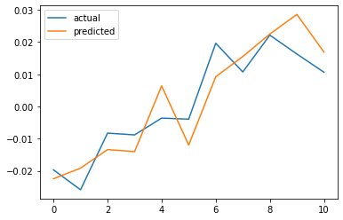

```
split_date: 2017-10-13 00:00:00
3170/3170 - 5s - loss: 0.0212 - 5s/epoch - 2ms/step
3170/3170 - 4s - loss: 0.0153 - 4s/epoch - 1ms/step
3170/3170 - 4s - loss: 0.0146 - 4s/epoch - 1ms/step
3170/3170 - 5s - loss: 0.0142 - 5s/epoch - 1ms/step
3170/3170 - 4s - loss: 0.0139 - 4s/epoch - 1ms/step
```

[5 more figures not shown]

```python
neurons_lst = np.arange(32, 168, 8)
neurons_dic = {}

for neurons in neurons_lst:
    split_date = list(df["Date"][-(2*window_len+1):])[0]
    print("split_date:",split_date)

    #Split the training and test set
    training_set, test_set = df[df['Date'] < split_date], df[df['Date'] >= split_date]
    training_set = training_set.drop(['Date','Label', 'OpenInt'], 1)
    test_set = test_set.drop(['Date','Label','OpenInt'], 1)

    #Create windows for training
    LSTM_training_inputs = []
    for i in range(len(training_set)-window_len):
        temp_set = training_set[i:(i+window_len)].copy()

        for col in list(temp_set):
            temp_set[col] = temp_set[col]/temp_set[col].iloc[0] - 1

        LSTM_training_inputs.append(temp_set)
    LSTM_training_inputs
    LSTM_training_outputs = (training_set['Close'][window_len:].values/training_set[
        'Close'][:-window_len].values)-1

    LSTM_training_inputs = [np.array(LSTM_training_input) for LSTM_training_input in LSTM_training_inputs]
    LSTM_training_inputs = np.array(LSTM_training_inputs)

    # Create windows for testing
    LSTM_test_inputs = []
    for i in range(len(test_set)-window_len):
        temp_set = test_set[i:(i+window_len)].copy()

        for col in list(temp_set):
            temp_set[col] = temp_set[col]/temp_set[col].iloc[0] - 1

        LSTM_test_inputs.append(temp_set)
    LSTM_test_outputs = (test_set['Close'][window_len:].values/test_set['Close'][:-window_len].values)-1

    LSTM_test_inputs = [np.array(LSTM_test_inputs) for LSTM_test_inputs in LSTM_test_inputs]
    LSTM_test_inputs = np.array(LSTM_test_inputs)

    # initialise model architecture
    nn_model = build_model(LSTM_training_inputs, output_size=1, neurons = neurons)
    # model output is next price normalised to 10th previous closing price train model on data
    # note: eth_history contains information on the training error per epoch
    nn_history = nn_model.fit(LSTM_training_inputs, LSTM_training_outputs,
                                epochs=5, batch_size=1, verbose=2, shuffle=True)
    plt.plot(LSTM_test_outputs, label = "actual")
    plt.plot(nn_model.predict(LSTM_test_inputs), label = "predicted")
    plt.legend()
    plt.show()
    MAE = mean_absolute_error(LSTM_test_outputs, nn_model.predict(LSTM_test_inputs))
    neurons_dic[neurons] = MAE
neurons_result = pd.DataFrame(neurons_dic.values(), neurons_dic.keys()).rename(columns={0: "MAE"})
```

```
          MAE
152  0.005162
```

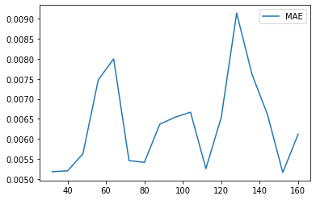

```python
print(neurons_result.loc[neurons_result["MAE"] == neurons_result["MAE"].min()])
neurons_result.plot()
```

The NN architecture is made of neurons, which are simulations of human brain, which is a process that generates some inputs, then converts and transfers them to the node (activation function) and then returns an output NN architecture also contains the bias, transfer function and activation function.

## Epochs

```
split_date: 2017-10-13 00:00:00
3170/3170 - 5s - loss: 0.0361 - 5s/epoch - 2ms/step
3170/3170 - 4s - loss: 0.0359 - 4s/epoch - 1ms/step
3170/3170 - 4s - loss: 0.0358 - 4s/epoch - 1ms/step
3170/3170 - 4s - loss: 0.0358 - 4s/epoch - 1ms/step
3170/3170 - 4s - loss: 0.0358 - 4s/epoch - 1ms/step
```

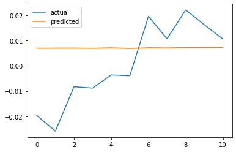

```
split_date: 2017-10-13 00:00:00
3170/3170 - 5s - loss: 0.0361 - 5s/epoch - 2ms/step
3170/3170 - 5s - loss: 0.0359 - 5s/epoch - 1ms/step
3170/3170 - 4s - loss: 0.0359 - 4s/epoch - 1ms/step
3170/3170 - 4s - loss: 0.0359 - 4s/epoch - 1ms/step
3170/3170 - 4s - loss: 0.0358 - 4s/epoch - 1ms/step
3170/3170 - 4s - loss: 0.0358 - 4s/epoch - 1ms/step
```

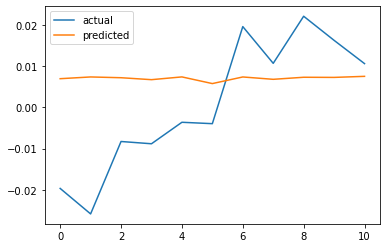

```
split_date: 2017-10-13 00:00:00
3170/3170 - 5s - loss: 0.0360 - 5s/epoch - 2ms/step
3170/3170 - 4s - loss: 0.0359 - 4s/epoch - 1ms/step
3170/3170 - 4s - loss: 0.0359 - 4s/epoch - 1ms/step
3170/3170 - 4s - loss: 0.0358 - 4s/epoch - 1ms/step
3170/3170 - 5s - loss: 0.0358 - 5s/epoch - 1ms/step
3170/3170 - 4s - loss: 0.0357 - 4s/epoch - 1ms/step
3170/3170 - 4s - loss: 0.0356 - 4s/epoch - 1ms/step
```

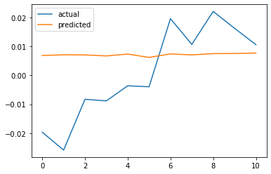

```
split_date: 2017-10-13 00:00:00
3170/3170 - 5s - loss: 0.0360 - 5s/epoch - 2ms/step
3170/3170 - 4s - loss: 0.0359 - 4s/epoch - 1ms/step
3170/3170 - 4s - loss: 0.0359 - 4s/epoch - 1ms/step
3170/3170 - 4s - loss: 0.0359 - 4s/epoch - 1ms/step
3170/3170 - 4s - loss: 0.0359 - 4s/epoch - 1ms/step
3170/3170 - 5s - loss: 0.0359 - 5s/epoch - 1ms/step
3170/3170 - 4s - loss: 0.0359 - 4s/epoch - 1ms/step
3170/3170 - 4s - loss: 0.0358 - 4s/epoch - 1ms/step
```

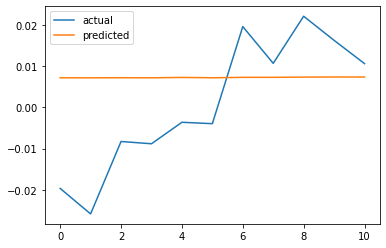

```
split_date: 2017-10-13 00:00:00
3170/3170 - 5s - loss: 0.0360 - 5s/epoch - 1ms/step
3170/3170 - 4s - loss: 0.0359 - 4s/epoch - 1ms/step
3170/3170 - 4s - loss: 0.0359 - 4s/epoch - 1ms/step
3170/3170 - 4s - loss: 0.0359 - 4s/epoch - 1ms/step
3170/3170 - 4s - loss: 0.0359 - 4s/epoch - 1ms/step
3170/3170 - 4s - loss: 0.0359 - 4s/epoch - 1ms/step
3170/3170 - 4s - loss: 0.0359 - 4s/epoch - 1ms/step
3170/3170 - 4s - loss: 0.0359 - 4s/epoch - 1ms/step
3170/3170 - 4s - loss: 0.0359 - 4s/epoch - 1ms/step
```

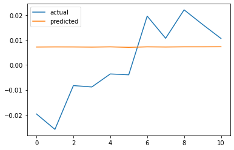

```
split_date: 2017-10-13 00:00:00
3170/3170 - 5s - loss: 0.0360 - 5s/epoch - 2ms/step
3170/3170 - 4s - loss: 0.0359 - 4s/epoch - 1ms/step
3170/3170 - 4s - loss: 0.0359 - 4s/epoch - 1ms/step
3170/3170 - 4s - loss: 0.0359 - 4s/epoch - 1ms/step
3170/3170 - 5s - loss: 0.0359 - 5s/epoch - 1ms/step
3170/3170 - 4s - loss: 0.0359 - 4s/epoch - 1ms/step
3170/3170 - 5s - loss: 0.0359 - 5s/epoch - 1ms/step
3170/3170 - 4s - loss: 0.0358 - 4s/epoch - 1ms/step
3170/3170 - 4s - loss: 0.0358 - 4s/epoch - 1ms/step
3170/3170 - 4s - loss: 0.0358 - 4s/epoch - 1ms/step
```

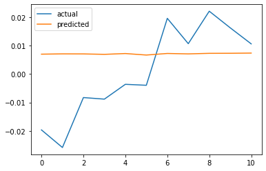

```
split_date: 2017-10-13 00:00:00
3170/3170 - 5s - loss: 0.0360 - 5s/epoch - 2ms/step
3170/3170 - 4s - loss: 0.0359 - 4s/epoch - 1ms/step
3170/3170 - 4s - loss: 0.0359 - 4s/epoch - 1ms/step
3170/3170 - 4s - loss: 0.0359 - 4s/epoch - 1ms/step
3170/3170 - 4s - loss: 0.0359 - 4s/epoch - 1ms/step
3170/3170 - 4s - loss: 0.0359 - 4s/epoch - 1ms/step
3170/3170 - 4s - loss: 0.0358 - 4s/epoch - 1ms/step
3170/3170 - 4s - loss: 0.0358 - 4s/epoch - 1ms/step
3170/3170 - 4s - loss: 0.0358 - 4s/epoch - 1ms/step
3170/3170 - 4s - loss: 0.0357 - 4s/epoch - 1ms/step
3170/3170 - 4s - loss: 0.0356 - 4s/epoch - 1ms/step
```

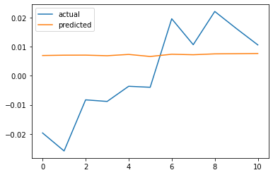

```
split_date: 2017-10-13 00:00:00
3170/3170 - 5s - loss: 0.0360 - 5s/epoch - 2ms/step
3170/3170 - 4s - loss: 0.0359 - 4s/epoch - 1ms/step
3170/3170 - 4s - loss: 0.0359 - 4s/epoch - 1ms/step
3170/3170 - 4s - loss: 0.0359 - 4s/epoch - 1ms/step
3170/3170 - 4s - loss: 0.0359 - 4s/epoch - 1ms/step
3170/3170 - 4s - loss: 0.0358 - 4s/epoch - 1ms/step
3170/3170 - 4s - loss: 0.0358 - 4s/epoch - 1ms/step
3170/3170 - 4s - loss: 0.0358 - 4s/epoch - 1ms/step
3170/3170 - 4s - loss: 0.0357 - 4s/epoch - 1ms/step
3170/3170 - 4s - loss: 0.0356 - 4s/epoch - 1ms/step
3170/3170 - 4s - loss: 0.0356 - 4s/epoch - 1ms/step
3170/3170 - 4s - loss: 0.0354 - 4s/epoch - 1ms/step
```

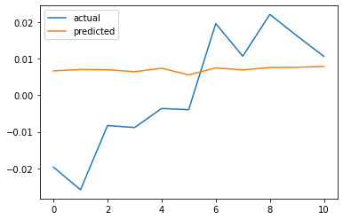

```
split_date: 2017-10-13 00:00:00
3170/3170 - 5s - loss: 0.0360 - 5s/epoch - 2ms/step
3170/3170 - 4s - loss: 0.0359 - 4s/epoch - 1ms/step
3170/3170 - 4s - loss: 0.0358 - 4s/epoch - 1ms/step
3170/3170 - 4s - loss: 0.0357 - 4s/epoch - 1ms/step
3170/3170 - 4s - loss: 0.0357 - 4s/epoch - 1ms/step
3170/3170 - 4s - loss: 0.0356 - 4s/epoch - 1ms/step
3170/3170 - 4s - loss: 0.0355 - 4s/epoch - 1ms/step
3170/3170 - 4s - loss: 0.0354 - 4s/epoch - 1ms/step
3170/3170 - 4s - loss: 0.0353 - 4s/epoch - 1ms/step
3170/3170 - 4s - loss: 0.0352 - 4s/epoch - 1ms/step
3170/3170 - 4s - loss: 0.0350 - 4s/epoch - 1ms/step
3170/3170 - 4s - loss: 0.0348 - 4s/epoch - 1ms/step
3170/3170 - 4s - loss: 0.0345 - 4s/epoch - 1ms/step
```

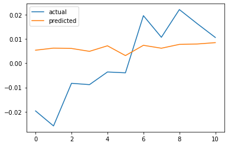

```
split_date: 2017-10-13 00:00:00
3170/3170 - 5s - loss: 0.0360 - 5s/epoch - 1ms/step
3170/3170 - 4s - loss: 0.0359 - 4s/epoch - 1ms/step
3170/3170 - 4s - loss: 0.0359 - 4s/epoch - 1ms/step
3170/3170 - 4s - loss: 0.0359 - 4s/epoch - 1ms/step
3170/3170 - 4s - loss: 0.0359 - 4s/epoch - 1ms/step
3170/3170 - 4s - loss: 0.0359 - 4s/epoch - 1ms/step
3170/3170 - 4s - loss: 0.0359 - 4s/epoch - 1ms/step
3170/3170 - 4s - loss: 0.0358 - 4s/epoch - 1ms/step
3170/3170 - 4s - loss: 0.0358 - 4s/epoch - 1ms/step
3170/3170 - 4s - loss: 0.0358 - 4s/epoch - 1ms/step
3170/3170 - 4s - loss: 0.0357 - 4s/epoch - 1ms/step
3170/3170 - 5s - loss: 0.0357 - 5s/epoch - 1ms/step
3170/3170 - 4s - loss: 0.0356 - 4s/epoch - 1ms/step
3170/3170 - 4s - loss: 0.0355 - 4s/epoch - 1ms/step
```

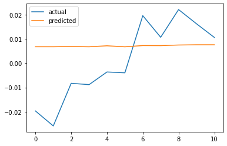

```
split_date: 2017-10-13 00:00:00
3170/3170 - 5s - loss: 0.0360 - 5s/epoch - 2ms/step
3170/3170 - 4s - loss: 0.0359 - 4s/epoch - 1ms/step
3170/3170 - 4s - loss: 0.0359 - 4s/epoch - 1ms/step
3170/3170 - 4s - loss: 0.0359 - 4s/epoch - 1ms/step
3170/3170 - 4s - loss: 0.0359 - 4s/epoch - 1ms/step
3170/3170 - 4s - loss: 0.0359 - 4s/epoch - 1ms/step
3170/3170 - 4s - loss: 0.0359 - 4s/epoch - 1ms/step
3170/3170 - 5s - loss: 0.0359 - 5s/epoch - 1ms/step
3170/3170 - 4s - loss: 0.0358 - 4s/epoch - 1ms/step
3170/3170 - 4s - loss: 0.0358 - 4s/epoch - 1ms/step
3170/3170 - 4s - loss: 0.0357 - 4s/epoch - 1ms/step
3170/3170 - 4s - loss: 0.0356 - 4s/epoch - 1ms/step
3170/3170 - 4s - loss: 0.0354 - 4s/epoch - 1ms/step
3170/3170 - 4s - loss: 0.0351 - 4s/epoch - 1ms/step
3170/3170 - 4s - loss: 0.0347 - 4s/epoch - 1ms/step
```

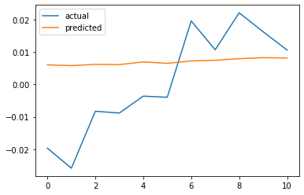

```
split_date: 2017-10-13 00:00:00
3170/3170 - 5s - loss: 0.0360 - 5s/epoch - 1ms/step
3170/3170 - 4s - loss: 0.0359 - 4s/epoch - 1ms/step
3170/3170 - 4s - loss: 0.0359 - 4s/epoch - 1ms/step
3170/3170 - 4s - loss: 0.0359 - 4s/epoch - 1ms/step
3170/3170 - 4s - loss: 0.0359 - 4s/epoch - 1ms/step
3170/3170 - 4s - loss: 0.0359 - 4s/epoch - 1ms/step
3170/3170 - 4s - loss: 0.0359 - 4s/epoch - 1ms/step
3170/3170 - 4s - loss: 0.0359 - 4s/epoch - 1ms/step
3170/3170 - 4s - loss: 0.0359 - 4s/epoch - 1ms/step
3170/3170 - 4s - loss: 0.0359 - 4s/epoch - 1ms/step
3170/3170 - 4s - loss: 0.0359 - 4s/epoch - 1ms/step
3170/3170 - 4s - loss: 0.0359 - 4s/epoch - 1ms/step
3170/3170 - 4s - loss: 0.0359 - 4s/epoch - 1ms/step
3170/3170 - 4s - loss: 0.0359 - 4s/epoch - 1ms/step
3170/3170 - 4s - loss: 0.0358 - 4s/epoch - 1ms/step
3170/3170 - 4s - loss: 0.0358 - 4s/epoch - 1ms/step
```

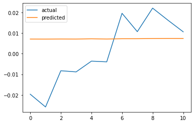

```
split_date: 2017-10-13 00:00:00
3170/3170 - 5s - loss: 0.0360 - 5s/epoch - 2ms/step
3170/3170 - 4s - loss: 0.0357 - 4s/epoch - 1ms/step
3170/3170 - 4s - loss: 0.0356 - 4s/epoch - 1ms/step
3170/3170 - 4s - loss: 0.0355 - 4s/epoch - 1ms/step
3170/3170 - 4s - loss: 0.0353 - 4s/epoch - 1ms/step
3170/3170 - 4s - loss: 0.0351 - 4s/epoch - 1ms/step
3170/3170 - 4s - loss: 0.0349 - 4s/epoch - 1ms/step
3170/3170 - 4s - loss: 0.0347 - 4s/epoch - 1ms/step
3170/3170 - 4s - loss: 0.0343 - 4s/epoch - 1ms/step
3170/3170 - 4s - loss: 0.0341 - 4s/epoch - 1ms/step
3170/3170 - 4s - loss: 0.0336 - 4s/epoch - 1ms/step
3170/3170 - 4s - loss: 0.0331 - 4s/epoch - 1ms/step
3170/3170 - 4s - loss: 0.0325 - 4s/epoch - 1ms/step
3170/3170 - 4s - loss: 0.0317 - 4s/epoch - 1ms/step
3170/3170 - 4s - loss: 0.0309 - 4s/epoch - 1ms/step
3170/3170 - 4s - loss: 0.0299 - 4s/epoch - 1ms/step
3170/3170 - 4s - loss: 0.0288 - 4s/epoch - 1ms/step
```

[3 more figures not shown]

```python
epochs_lst = range(5, 20)
epochs_dic = {}

for epochs in epochs_lst:
    def this_build_model(inputs, output_size, neurons, activ_func="linear",
                         dropout=0.10, loss="mae", optimizer=optimizer):
        model = Sequential()

        model.add(LSTM(neurons, input_shape=(inputs.shape[1], inputs.shape[2])))
        model.add(Dropout(dropout))
        model.add(Dense(units=output_size))
        model.add(Activation(activ_func))

        model.compile(loss="mae", optimizer=optimizer)
        return model

    split_date = list(df["Date"][-(2*window_len+1):])[0]
    print("split_date:",split_date)

    #Split the training and test set
    training_set, test_set = df[df['Date'] < split_date], df[df['Date'] >= split_date]
    training_set = training_set.drop(['Date','Label', 'OpenInt'], 1)
    test_set = test_set.drop(['Date','Label','OpenInt'], 1)

    #Create windows for training
    LSTM_training_inputs = []
    for i in range(len(training_set)-window_len):
        temp_set = training_set[i:(i+window_len)].copy()

        for col in list(temp_set):
            temp_set[col] = temp_set[col]/temp_set[col].iloc[0] - 1

        LSTM_training_inputs.append(temp_set)
    LSTM_training_inputs
    LSTM_training_outputs = (training_set['Close'][window_len:].values/training_set[
        'Close'][:-window_len].values)-1

    LSTM_training_inputs = [np.array(LSTM_training_input) for LSTM_training_input in LSTM_training_inputs]
    LSTM_training_inputs = np.array(LSTM_training_inputs)

    # Create windows for testing
    LSTM_test_inputs = []
    for i in range(len(test_set)-window_len):
        temp_set = test_set[i:(i+window_len)].copy()

        for col in list(temp_set):
            temp_set[col] = temp_set[col]/temp_set[col].iloc[0] - 1

        LSTM_test_inputs.append(temp_set)
    LSTM_test_outputs = (test_set['Close'][window_len:].values/test_set[
        'Close'][:-window_len].values)-1

    LSTM_test_inputs = [np.array(LSTM_test_inputs) for LSTM_test_inputs in LSTM_test_inputs]
    LSTM_test_inputs = np.array(LSTM_test_inputs)

    # initialise model architecture
    nn_model = this_build_model(LSTM_training_inputs, output_size=1, neurons = 32)
    # model output is next price normalised to 10th previous closing price train model on data
    # note: eth_history contains information on the training error per epoch
    nn_history = nn_model.fit(LSTM_training_inputs, LSTM_training_outputs,
                                epochs=epochs, batch_size=1, verbose=2, shuffle=True)
    plt.plot(LSTM_test_outputs, label = "actual")
    plt.plot(nn_model.predict(LSTM_test_inputs), label = "predicted")
    plt.legend()
    plt.show()
    MAE = mean_absolute_error(LSTM_test_outputs, nn_model.predict(LSTM_test_inputs))
    epochs_dic[epochs] = MAE
epochs_result = pd.DataFrame(epochs_dic.values(), epochs_dic.keys()).rename(columns={0: "MAE"})
```

```
         MAE
17  0.009772
```

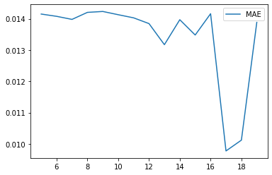

```python
print(epochs_result.loc[epochs_result["MAE"] == epochs_result["MAE"].min()])
epochs_result.plot()
```

In our model, one epoch means that we completed one forward algorithm and one backpropagation. With the increase of the number of epochs, we get better outcomes (lower errors), and then the errors would get higher at some points due to overfitting.

## Conclusion

The parameters I choose hence are:

window length = 1

activation function = tanh

loss function = mse

dropout rate = 0.85

optimizer = nadam

neurons = 152

epochs = 17

```python
window_len = window_result.loc[window_result["MAE"] == window_result["MAE"].min()].index[0]
loss = loss_result.loc[loss_result["Error"] == loss_result["Error"].min()].index[0]
activ_func = activation_result.loc[activation_result["MAE"] == activation_result["MAE"].min()].index[0]
dropout = dropout_result.loc[dropout_result["MAE"] == dropout_result["MAE"].min()].index[0]
optimizer = optimizer_result.loc[optimizer_result["MAE"] == optimizer_result["MAE"].min()].index[0]
neurons = neurons_result.loc[neurons_result["MAE"] == neurons_result["MAE"].min()].index[0]
epochs = epochs_result.loc[epochs_result["MAE"] == epochs_result["MAE"].min()].index[0]
```

```
split_date: 2017-11-08 00:00:00
3197/3197 - 4s - loss: 3.8853e-04 - 4s/epoch - 1ms/step
3197/3197 - 3s - loss: 3.6437e-04 - 3s/epoch - 871us/step
3197/3197 - 3s - loss: 3.5731e-04 - 3s/epoch - 869us/step
3197/3197 - 3s - loss: 3.6031e-04 - 3s/epoch - 847us/step
3197/3197 - 3s - loss: 3.5913e-04 - 3s/epoch - 818us/step
3197/3197 - 3s - loss: 3.5808e-04 - 3s/epoch - 858us/step
3197/3197 - 3s - loss: 3.5748e-04 - 3s/epoch - 887us/step
3197/3197 - 3s - loss: 3.6086e-04 - 3s/epoch - 864us/step
3197/3197 - 3s - loss: 3.5506e-04 - 3s/epoch - 872us/step
3197/3197 - 3s - loss: 3.5845e-04 - 3s/epoch - 883us/step
3197/3197 - 3s - loss: 3.5793e-04 - 3s/epoch - 852us/step
3197/3197 - 3s - loss: 3.5977e-04 - 3s/epoch - 835us/step
3197/3197 - 3s - loss: 3.5791e-04 - 3s/epoch - 835us/step
3197/3197 - 3s - loss: 3.5756e-04 - 3s/epoch - 839us/step
3197/3197 - 3s - loss: 3.5714e-04 - 3s/epoch - 881us/step
3197/3197 - 3s - loss: 3.5969e-04 - 3s/epoch - 1ms/step
3197/3197 - 3s - loss: 3.5872e-04 - 3s/epoch - 1ms/step
```

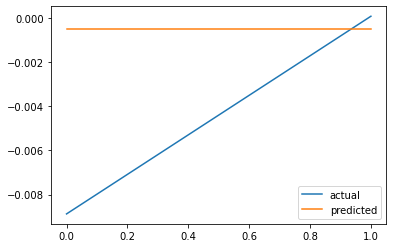

```
MAE:  0.004486353821837541
```

```python
def test_build_model(inputs, output_size, neurons, activ_func=activ_func,
                     dropout=dropout, loss=loss, optimizer=optimizer):
    model = Sequential()
    model.add(LSTM(neurons, input_shape=(inputs.shape[1], inputs.shape[2])))
    model.add(Dropout(dropout))
    model.add(Dense(units=output_size))
    model.add(Activation(activ_func))
    model.compile(loss=loss, optimizer=optimizer)
    return model

split_date = list(df["Date"][-(2*window_len+1):])[0]
print("split_date:",split_date)

# Split the training and test set
training_set, test_set = df[df['Date'] < split_date], df[df['Date'] >= split_date]
training_set = training_set.drop(['Date','Label', 'OpenInt'], 1)
test_set = test_set.drop(['Date','Label','OpenInt'], 1)

# Create windows for training
LSTM_training_inputs = []
for i in range(len(training_set)-window_len):
    temp_set = training_set[i:(i+window_len)].copy()

    for col in list(temp_set):
        temp_set[col] = temp_set[col]/temp_set[col].iloc[0] - 1
    LSTM_training_inputs.append(temp_set)

LSTM_training_inputs
LSTM_training_outputs = (training_set['Close'][window_len:].values/training_set[
    'Close'][:-window_len].values)-1

LSTM_training_inputs = [np.array(LSTM_training_input) for LSTM_training_input in LSTM_training_inputs]
LSTM_training_inputs = np.array(LSTM_training_inputs)

# Create windows for testing
LSTM_test_inputs = []
for i in range(len(test_set)-window_len):
    temp_set = test_set[i:(i+window_len)].copy()

    for col in list(temp_set):
        temp_set[col] = temp_set[col]/temp_set[col].iloc[0] - 1

    LSTM_test_inputs.append(temp_set)
LSTM_test_outputs = (test_set['Close'][window_len:].values/test_set['Close'][:-window_len].values)-1

LSTM_test_inputs = [np.array(LSTM_test_inputs) for LSTM_test_inputs in LSTM_test_inputs]
LSTM_test_inputs = np.array(LSTM_test_inputs)

# initialise model architecture
nn_model = test_build_model(LSTM_training_inputs, output_size=1, neurons = neurons)
# model output is next price normalised to 10th previous closing price train model on data
# note: eth_history contains information on the training error per epoch
nn_history = nn_model.fit(LSTM_training_inputs, LSTM_training_outputs,
                            epochs=epochs, batch_size=1, verbose=2, shuffle=True)
plt.plot(LSTM_test_outputs, label = "actual")
plt.plot(nn_model.predict(LSTM_test_inputs), label = "predicted")
plt.legend()
plt.show()
MAE = mean_absolute_error(LSTM_test_outputs, nn_model.predict(LSTM_test_inputs))
print("MAE: ", MAE)
```

# Part 2

```python
def sigmoid(p):
    return 1/(1+math.exp(-p))

def backpropagation(x=1, y=4, z=5, target=np.array([0.1, 0.05]), lr=0.01):
    w1, w2, w3, w4, w5, w6, w7, w8, w9, w10 = 0.1, 0.2, 0.3, 0.4, 0.5, 0.6, 0.7, 0.8, 0.9, 0.1
    h_1, h_2 = sigmoid(w1*x + w3*y + w5*z + 0.5), sigmoid(w2*x + w4*y + w6*z + 0.5)
    o_1, o_2 = sigmoid(w7*h_1 + w9*h_2 + 0.5), sigmoid(w8*h_1 + w10*h_2 + 0.5)
    sse = 1/2 * sum((target-np.array([o_1, o_2]))**2)
    sse_o1, sse_o2 = o_1 - target[0], o_2 - target[1]
    o1_n1, o2_n2 = o_1 * (1 - o_1), o_2 * (1 - o_2)
    n1_w7, n1_w9, n2_w8, n2_w10 = h_1, h_2, h_1, h_2
    sse_w7, sse_w8 = sse_o1 * o1_n1 * n1_w7, sse_o2 * o2_n2 * n2_w8
    sse_w9, sse_w10 = sse_o1 * o1_n1 * n1_w9, sse_o2 * o2_n2 * n2_w10
    new_w7, new_w8, new_w9, new_w10 = w7 + lr * n1_w7, w8 + lr * n2_w8, w9+ lr * n1_w9, w10 + lr * n2_w10
    h1_m1, h2_m2 = h_1 * (1 - h_1), h_2 * (1 - h_2)
    m1_w1, m1_w3, m1_w5, m2_w2, m2_w4, m2_w6 = w1, w3, w5, w2, w4, w6
    h1_w1, h1_w3, h1_w5 = h1_m1 * m1_w1, h1_m1 * m1_w3, h1_m1 * m1_w5
    h2_w2, h2_w4, h2_w6 = h2_m2 * m2_w2, h2_m2 * m2_w4, h2_m2 * m2_w6
    n1_h1, n1_h2, n2_h1, n2_h2 = w7, w9, w8, w10
    sse_h1, sse_h2 = o1_n1 * n1_h1 + o2_n2 * n2_h1, o1_n1 * n1_h2 + o2_n2 * n2_h2
    sse_m1, sse_m2 = sse_h1 * h1_m1, sse_h2 * h2_m2
    sse_w1, sse_w3, sse_w5 = sse_h1 * h1_w1, sse_h1 * h1_w3, sse_h1 * h1_w5
    sse_w2, sse_w4, sse_w6 = sse_h2 * h2_w2, sse_h2 * h2_w4, sse_h2 * h2_w6
    new_w1, new_w3, new_w5 = w1 + lr * sse_w1, w3 + lr * sse_w3, w5 + lr * sse_w5
    new_w2, new_w4, new_w6 = w2 + lr * sse_w2, w4 + lr * sse_w4, w6 + lr * sse_w6
    return {"new w1": new_w1, "new w2": new_w2, "new w3": new_w3, "new w4": new_w4, "new w5": new_w5,
            "new w6": new_w6, "new w7": new_w7, "new w8": new_w8, "new w9": new_w9, "new w10": new_w10}

backpropagation()
```

```
{'new w1': 0.10000259641466082,
 'new w2': 0.2000010319300706,
 'new w3': 0.3000077892439824,
 'new w4': 0.4000020638601412,
 'new w5': 0.500012982073304,
 'new w6': 0.6000030957902117,
 'new w7': 0.7098661308217233,
 'new w8': 0.8098661308217234,
 'new w9': 0.9099503319834995,
 'new w10': 0.10995033198349943}
```